### STATISTICAL INFERENCE:EMPLOYEE ENGAGEMENT CASE STUDY

#### Background:Employee engagement is defined through three attributes that include the extent to which employees:

#### – Say - speak positively about the organization to co-workers, potential employees and customers

#### – Stay - have an intense sense of belonging and desire to be a part of the organization

#### – Strive - are motivated and exert effort towards success in their job and for the company

#### The employee engagement score is obtained based on 6 questions. The score ranges from 0 to 100 where higher score indicates more engaged employee.

#### In addition, the feedback is obtained from employees about proposed “4-day week with extra working hours”. The feedback rating is 1-4 where higher score indicates higher agreement level

#### Objective is to measure the employee engagement level and to understand factors influencing it.

#### a) Is average employee engagement score significantly greater than 50?

#### b) Does average employee engagement score differ for 3 departments?

#### c) Does average employee engagement score differ for Male and Female employees?

#### d) How is feedback about proposed “4-day week with extra working hours” varying by department/gender?

#### Import data

```r
data<-read.csv("EMPLOYEE ENGAGEMENT DATA.csv",header = T)
head(data)
```

```
  EMPNO    DEPT GENDER EESCORE FEEDBACK
1    11      IT   Male   32.13        3
2   830      IT   Male   54.13        2
3    65 FINANCE   Male   44.25        4
4    66   SALES   Male   37.75        3
5   130      IT   Male   53.50        2
6   132      IT   Male   48.63        3
```

#### Data Description Table

| Column name | Column description |
| --- | --- |
| EMPNO | Employee ID |
| DEPT | Department of employee |
| GENDER | Gender of employee |
| EESCORE | Employee Engagement Score |
| FEEDBACK | Employee feedback on '4-day week with extra working hours'. The feedback rating is 1-4 where higher score indicates higher agreement level. |

#### Box-Whisker Plot for Employee Engagement Score-Overall

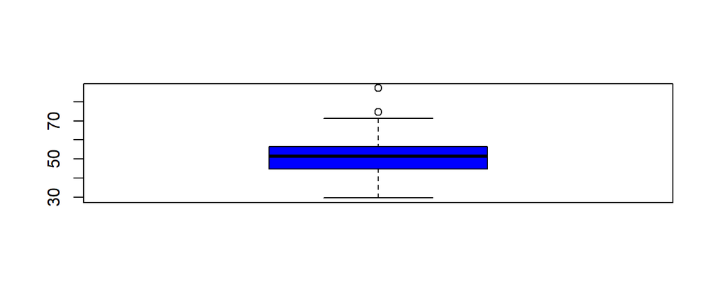

```r
boxplot(data$EESCORE,col="blue")
```

#### Comment: The distribution of Employee Engagement score is symmetric with two outliers

#### Box-Whisker Plot for Employee Engagement Score- By Gender

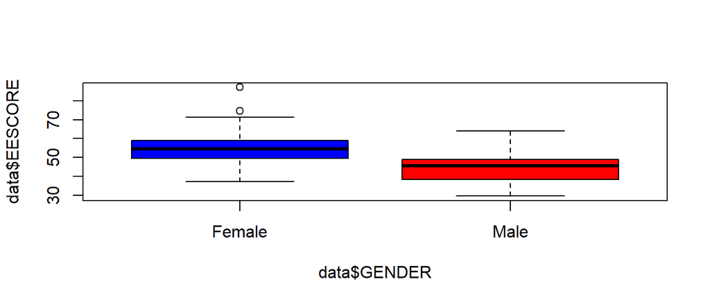

```r
boxplot(data$EESCORE~data$GENDER,col=c("blue","red","green"))
```

#### Comment: Median score for female employees is much higher than median score for male employees

#### Box-Whisker Plot for Employee Engagement Score- By Department

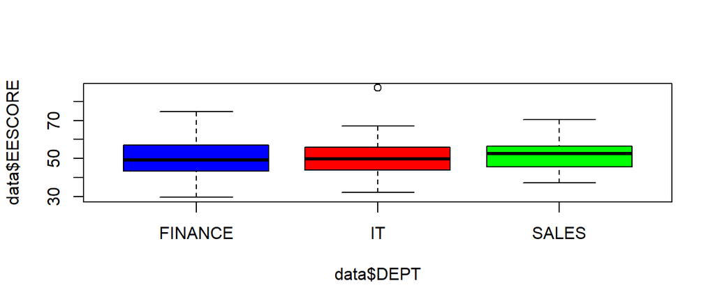

```r
boxplot(data$EESCORE~data$DEPT,col=c("blue","red","green"))
```

#### Comment: The distribution of score in 3 departments looks similar

#### Summary Table for Employee Engagement Score by Gender

```r
library(dplyr)
gender_summ<-data %>% group_by(GENDER) %>% summarise(n=length(EESCORE),Mean=round(mean(EESCORE),2),
                                                     SD=round(sd(EESCORE),2),min=min(EESCORE),max=max(EESCORE)) %>% as.data.frame()
gender_summ
```

```
  GENDER  n  Mean   SD   min   max
1 Female 55 55.07 9.44 37.25 87.13
2   Male 31 44.81 7.83 29.63 64.00
```

#### Summary Table for Employee Engagement Score by Department

```r
dept_summ<-data %>% group_by(DEPT) %>% summarise(n=length(EESCORE),Mean=round(mean(EESCORE),2),
                    SD=round(sd(EESCORE),2),min=min(EESCORE),max=max(EESCORE)) %>% as.data.frame()
dept_summ
```

```
     DEPT  n  Mean    SD   min   max
1 FINANCE 28 50.09 11.02 29.63 74.63
2      IT 32 51.11 10.29 32.13 87.13
3   SALES 26 53.07  9.07 37.25 70.38
```

#### “Normality” testing for Employee Engagement Score-Overall

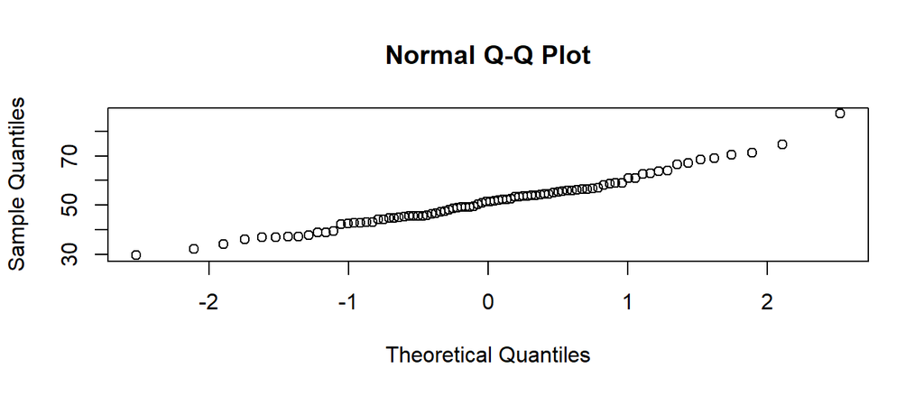

```r
qqnorm(data$EESCORE)
```

```r
shapiro.test(data$EESCORE)
```

```
    Shapiro-Wilk normality test

data:  data$EESCORE
W = 0.9777, p-value = 0.143
```

#### Comment:Employee Engagement Score is normally distributed

###### By Gender

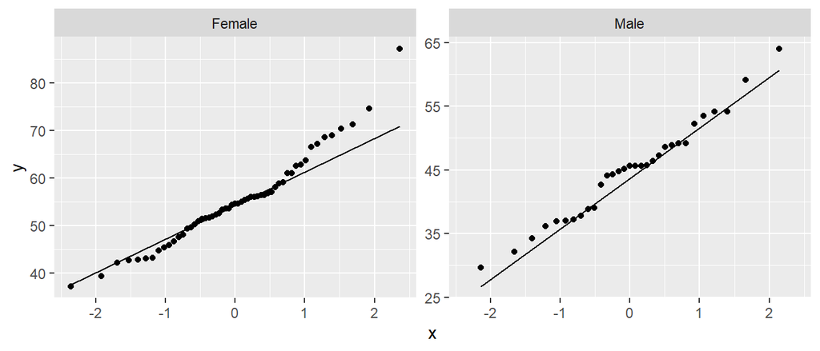

```r
library(ggplot2)
data %>%
  ggplot(aes(sample = EESCORE)) +
  geom_qq() + geom_qq_line() +
  facet_wrap(~GENDER, scales = "free_y")
```

```r
aggregate(EESCORE ~ GENDER,data = data,
          FUN = function(x) {y <- shapiro.test(x); c(y$p.value)})
```

```
  GENDER    EESCORE
1 Female 0.06017936
2   Male 0.74961844
```

#### Comment: Employment Engagement Score for both genders is normally distributed

###### By Department

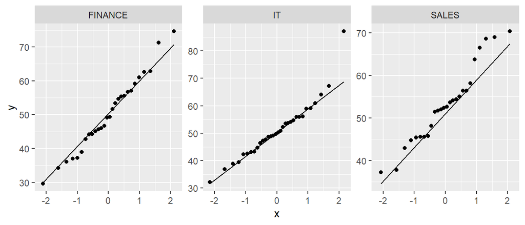

```r
data %>%
  ggplot(aes(sample = EESCORE)) +
  geom_qq() + geom_qq_line() +
  facet_wrap(~DEPT, scales = "free_y")
```

```r
aggregate(EESCORE ~ DEPT,data = data,
          FUN = function(x) {y <- shapiro.test(x); c(y$p.value)})
```

```
     DEPT    EESCORE
1 FINANCE 0.90882282
2      IT 0.02843683
3   SALES 0.24201247
```

#### Comment: Employment score for Finance and Sales departments is normally distributed but for IT department it is not normally distributed

#### Check if average employee engagement score significantly greater than 50 (One sample t test)

```r
t.test(data$EESCORE, alternative="greater", mu=50)
```

```
    One Sample t-test

data:  data$EESCORE
t = 1.2508, df = 85, p-value = 0.1072
alternative hypothesis: true mean is greater than 50
95 percent confidence interval:
 49.54929      Inf
sample estimates:
mean of x
 51.36791
```

#### Do not reject H0 and conclude that average employee engagement score is not greater than 50 (p-value=0.1072 is greater than 0.05)

#### Check if average employee engagement score differ for 3 departments(One way anova)

```r
anovatable<-aov(formula=EESCORE~DEPT, data=data)
summary(anovatable)
```

```
            Df Sum Sq Mean Sq F value Pr(>F)
DEPT         2    123   61.47   0.592  0.556
Residuals   83   8619  103.85
```

#### Comment: Average employee engagement score is same for 3 departments since p-value=0.556 is greater than 0.05

#### Check if average employee engagement score differ for Male and Female employees(Independent samples t test)

```r
t.test(EESCORE~GENDER, alternative="two.sided",data=data,var.equal=TRUE)
```

```
    Two Sample t-test

data:  EESCORE by GENDER
t = 5.1332, df = 84, p-value = 1.812e-06
alternative hypothesis: true difference in means between group Female and group Male is not equal to 0
95 percent confidence interval:
  6.285999 14.236487
sample estimates:
mean in group Female   mean in group Male
            55.06673             44.80548
```

#### Comment: There is significant difference between average employee engagement score for Male and Female employees since p-value=0.000001812 is less than 0.05

#### To analzye the effects gender,department and interaction gender * department, two way analysis of variance is used.

```r
anovatable2<-aov(EESCORE~GENDER+DEPT+GENDER*DEPT,data=data)
summary(anovatable2)
```

```
            Df Sum Sq Mean Sq F value   Pr(>F)
GENDER       1   2087  2087.5  27.062 1.48e-06 ***
DEPT         2     38    18.9   0.244   0.7838
GENDER:DEPT  2    446   223.0   2.891   0.0614 .
Residuals   80   6171    77.1
---
Signif. codes:  0 '***' 0.001 '**' 0.01 '*' 0.05 '.' 0.1 ' ' 1
```

#### Comment: The average employee engagement scores are equal for 3 departments but differ for “Male” and “Female” employees.

#### The interaction effect Gender * Department is insignificant.

#### Check if feedback about proposed “4-day week with extra working hours” varying by gender. Here, non-parametric test (Mann-Whitney-Wilcoxon ) is used since the variable is measured on ordinal scale (independent samples t test is not appropriate)

```r
wilcox.test(FEEDBACK~GENDER,data=data)
```

```
    Wilcoxon rank sum test with continuity correction

data:  FEEDBACK by GENDER
W = 831, p-value = 0.8405
alternative hypothesis: true location shift is not equal to 0
```

#### Comment: Feedback about proposed “4-day week with extra working hours” is same for both genders since p-value=0.8405 is greater than 0.05

#### Check if feedback about proposed “4-day week with extra working hours” varying by department.Here, non-parametric test (Kruskal Wallis) is used since the variable is measured on ordinal scale (independent samples t test is not appropriate)

```r
kruskal.test(FEEDBACK~DEPT,data=data)
```

```
    Kruskal-Wallis rank sum test

data:  FEEDBACK by DEPT
Kruskal-Wallis chi-squared = 1.3292, df = 2, p-value = 0.5145
```

#### Comment: Feedback about proposed “4-day week with extra working hours” is same for all 3 departments since p-value=0.5145 is greater than 0.05